# K_means_clustering_algorithm

## Author: Marktus A Atanga

## School: Johns Hopkins University

## Class: Introduction to Machine Learning

## Algorithm: K-maeans clustering from Scratch

## Analysis Approach:

1. Brieff overview of the algorithm
2. Data loading, cleaning and exploration
3. Data standardization
4. Split data into train and test
5. Model selection
6. Model building
7. Model assessement

## Clustering Algorithms

The goal of clustering is to identify “natural” subgroups within a data set. So, it is more of a data discovery activity. Clustering algorithms use a similarity metric to identify “groupings” in the data. Most of the similarity metrics are the distance metrics such as Minkowski Metrics($L_k$ norms): Examples of the Minkowski metrics are Manhattan/city-block distance($L_1$ norm), Euclidean distance($L_2$ norm), and Max-coordinate distance ($L_\infty$ norm).

The the Minkowski distance metrics is given by: $d_m(X^r, X^s) = [\sum_{j=1}^d |X_j^r - X_j^s|^p]^{\frac{1}{p}}$

#### City block distance or Manhattan distance ($L_1$ norm) : p = 1

$d_cb(X^r, X^s) = [\sum_{j=1}^d |X_j^r - X_j^s|^1]^{\frac{1}{1}} = \sqrt{\sum_{j=1}^d |X_j^r - X_j^s|}$

#### Euclidean distance ($L_2$ norm): p = 2

$d_m(X^r, X^s) = [\sum_{j=1}^d |X_j^r - X_j^s|^2]^{\frac{1}{2}} = \sqrt{\sum_{j=1}^d |X_j^r - X_j^s|^2}$

How different is clustering from classification? Well, the two are similar. The only difference is that classification uses predefined classes in which the input data are assigned/labeled classes for training whereas clustering identifies structural similarities in input data and groups them according to those characteristics which differentiate them from other. Therefore, classification is a supervised machine learning but clustering is unsupervised mahcine learning. More detatils to the difference can be found in https://www.geeksforgeeks.org/ml-classification-vs-clustering/ .

### Families of clustering algorithms:

1. partitioning
2. hierarchical agglomerative
3. hierarchical divisive
4. spectral
5. adaptive resonance theory (ART)

### General approach to clustering

1. Choose appropriate attributes
2. Scale the data
3. set each variable’s mean = 0 and standard deviation = 1
4. Screen for outliers
5. Conduct cluster analyses
   1. select approach(es) and algorithm(s), e.g K-Means
   2. perform clustering
   3. evaluate number of clusters
   4. repeat
6. Interpret the clusters
7. Validate the results

### 1.0. What is the K-means algorithm and the math behind it?

The K-means algorithm is a semiparameteric algorithm. Unlike parametric algorithm that assume a certain single form of distribution of the input data, semiparametric approach allows a mixture of the distributions (mixture densities) to be used for estimating the input samples and is used when there are more than one structure to the data such that we cannot assume one form of distribution for the entire data. (Ethem Alpaydin, 2020). A common case of this application is in speech recognition where one word can be pronounced in several ways due to differences in accent, gender, etc. In such a scenario, we want to have a distribution for each form of pronounciation of the word such that we can reognize the persons gender, acccent. Hence the name semiparametric density estimation. I wish this was actually called multi-parametric density estimation instead of semiparametric because we are estimating several densities. - Just the thoughts of Marktus Atanga.

The K-means algorithm is one of the family of unsupervised semiparametric algorithms for clustering. K-means algorithm is a special case of the expectation maximization algorithm (check out the article on expectation maximization). Take for example pictures in which we need to encode from larger pixels (higher resolution) to lower resolution. Our goal is to encode the picture in a way that when we decode it back, it resamples the orignial picture as much as possible. By ecoding, we loose some information so we need to make sure we minimize the information lost. Thus, we have an optimization problem to solve. It turns out that the optimization problem is much complex and cannot be solved analytically and K-means is an iterative procedure to solve that problem. Read K-means clustering in Ethem Alpaydin, 2020.

#### Mixture densities formula

$p(x)= \sum_{i=1}^k p(x|G_i)P(G_i)$

Where $p(x|G_i)$ = component densities $P(G_i)$ = mixture proportions

Assuming we have samle $X = [{x^t}]_{t=1}^N$ and k reference vectors, $m_j, j = 1, 2, ...., k$. Think of k as the number of features in the data.

### 1.1. Assumptions in K-means algorithm

1. The data instances were generated by a mixture of 𝑘-Gaussian distributions
2. We do not know the means for these Gaussians and we want to these means
3. We also have no knowledge as to which Gaussian distribution generated which data points

### 1.2. Steps for the algorithm - Taken from Ethem Alpaydin, 2020

Remember we said the K-means algorithm is an example of expectation maximization algorithm. Hence the steps to follow are the similar as in expectation maximization algorithm.

1. Start with a guess for the number of means $m_i$ or K=2 initialized randomly. These means are the centroids
2. Perform the expectation step (E-step)

   For each iteration, calculate ${b^t}_i = (_{0 }^{1 if ||x^t - m_i|| = min_j||x^t - m_j||}$. ${b^t}_i$ are the estimated labels. ${b^t}_i$ =1 means that the $x^t$ belongs to the group $m_i$.
3. Perform the maximization step (M-step): Essentially a minimization step

   $E((m_i)_{i=1}^k |X)= \sum_{t=1}\sum_{i} {b^t}_i ||x^t - m_i||^2$

   Taking its derivative with respect to $m_i$ and setting to 0:

   $m_i = \frac{\sum_{t}{b^t}_i x^t}{\sum_{t} {b^t}_i}$

   $\sum_{i}^d||x^t - m_i||^2$ is the squared eucladian distance.

   $||x^t - m_i||^2 = \sum_{t=1}^n (x^t - m_i)^2 = x.x + y.y - 2x.y$

   The reference vector is set to the mean of all instances that it represents. This is an iterative procedure because once we calculate the new $m_i$ , $b_i ^t$ change and we need to recalculate it, which in turn affects $m_i$. So, step 2 and 3 are repeated till $m_i$ is stabilized.

### 1.3. Disadvantage:

The K-means search is a local search procedure, and the final $m_i$ is highly dependent on the initial $m_i$. Therefore the way in which $m_i$ is intialized can result in different outcome.

### 1.4. Methods for initializing $m_i$

1. Randomly select k instances as the initial $m_i$
2. Calculate the mean of all the data and all small random vectors to the mean to get intial $m_i$
3. Calculate the principal component, divide its range into k equal intervals, partitioning the data into k groups and take the means of these groups as the initial centers.

### 1.5. Example aaplication of K-means clustering

1. Use in vector quantiztion
2. Preprocessing before a classification or a regression can be performed

### 2.0. Model selection

In model building, we sometimes have so many attributes/features to choose from. When one decides on a model technique to use such as a naive Bayes, K-means, linear regresion, etc., the important question to ask oneself is whether all the attributes in the data are needed to build the model. The idea of model selection is to choose the optimal number of attributes/features that best fit a model for prediction or classification.

Thus, model selection is essentially an optimization problem where we want to find the best features/attributes that give the optimal model performance. Another advantage is that it helps prevent over-fitting the model with so much features. There are various techniques for selecting a model. Some of the techniques inclue stepwise regression, stepwise forward selection, stepwise backward elemination, and best subset selection.

Each of these model selection criteria has a metric for determining the optimal attributes for the model. In the case of regression analysis, the most widely used metrics are Mellow's Cp, R-squaure, ddjusted R-square, mean square error (MSE), Bayesian information criterion (BIC) aslso called Schwarz information criterion, Akaike information criterion (AIC). For all these metrics, we aim to find a model with the minimum criterior except the R-squaure, ddjusted R-square,where we want to maximise.

In the case of classification models, we can use metrics such as accuracy, error-rate, MSE, sensitivity, precision, or F_measure to determined the best model. The model with the lowest error-rate or MSE can be used. Or the model with the highest sensitivity, precission, specificity, accuracy, or F_measure can also be used. Ideally, the metric you use should be based on the design intent of the model.

### 2.1. Stepwise-Forward-Selection(SFS):

The steps involved in stepwise-forward selection are:

1. Define model success threshold, as a difference in model performance that is considered insignificant. This will be used as a stopping criterion in the model selection process.
2. First iterates through all the features to find the feature that gives best model score metric.
3. Perform pair-wise features iteration by combining the best feature with all other features, one at a time to find the best two features. Compare the model score against the score obtained in step 2. If the score metric difference is greater than the threshold, contiune to search for best 3 features
4. Reiterate to find the best 3 features, by combining the best 2 features in 3, withe remaining feaures. Check score metric against the sore in 3. If score difference is still greater than threshold, continue search for more features. In each iteration, compare model score metric against previous score metric. If the difference in core is not greater than the threshold, return all best features found.

### 3.0. Model performance assessement

Unlike classfication, we do not know the label before hand in clustering problems. Therfore, the assessement of model perfromance base on true positive, false positive, true negative, or false negative is not possible. Rather, the clustering algorithm is assessed using Silhouette coefficient.

### 3.1. Silhouette coefficient

This refers to a method of interpretation and validation of consistency within clusters of data. The technique provides a succinct graphical representation of how well each object has been clustered. The silhouette value is a measure of how similar an object is to its own cluster compared to other clusters. The silhouette ranges from −1 to +1, where a high value indicates that the object is well matched to its own cluster and poorly matched to neighboring clusters. If most objects have a high value, then the clustering configuration is appropriate. If many points have a low or negative value, then the clustering configuration may have too many or too few clusters. The silhouette can be calculated with any distance metric, such as the Euclidean distance or the Manhattan distance. https://en.wikipedia.org/wiki/Silhouette_(clustering)

1. Create a distance metric such as the euclidean distance
2. For each data point, calculate the distance between the data point and every orther point in the cluster. This is call cohesion or intra-cluster distance (a)
3. For each point in a cluster, calculate the distance between the point and points in the nearest cluster (b) . This is intercluster distance or separation. If we have more than two clusters, the intercluster distance is chosen from the closest cluster.
4. The Silhouette coefficient for each data point is given by:

   $S_i = \frac{(b-a)}{max(a, b)}$

   if a<b: $S_i = 1-\frac{a}{b}$

   if a>b: $S_i = \frac{b}{a} - 1$

   if a=b: $S_i = 0$

#### Interpretation of Silhouette coefficient:

1. Silhouette coefficient = -1 means that clustering of the data is wrong
2. Silhouette coefficient = 0 means that the data is indifferent/the clusters are the same
3. Silhouette coefficient = 1 means that both clusters are far apart - we we want.

```python
%matplotlib inline
```

```python
import sys
import time
import numpy as np
import pandas as pd
import matplotlib.pyplot as plt
pd.options.display.float_format = '{:,.6f}'.format
```

## 2. Load the synthetic data set

There might be some white spaces in the excel sheets so we add sep="\s*,\s*" and engine='python' to remove white space in the data.

```python
file1= r"proj2.csv" #data file

#create headers for the data
headers = ["x1", "x2", "x3", "x4", "x5", "class"]

#read data with pandas read csv function
df_syn = pd.read_csv(file1, sep="\s*,\s*", names = headers, engine='python')

#shuffle the data
df_syn.sample(frac = 1).head(10)
```

|  | x1 | x2 | x3 | x4 | x5 | class |
| --- | --- | --- | --- | --- | --- | --- |
| 2817 | 0.849304 | 3.426361 | 2.693934 | 6.955879 | 3.181809 | G |
| 639 | -1.856709 | 1.369730 | 0.988922 | 4.362314 | -1.640426 | G |
| 3278 | 0.134534 | 1.563787 | 0.805577 | 5.278299 | -0.072994 | G |
| 7179 | 3.789696 | 1.694093 | 8.420089 | -1.502668 | 2.544510 | H |
| 2507 | 1.800042 | 4.347188 | 2.226637 | 7.577890 | 0.521121 | G |
| 8772 | 3.742534 | -0.192271 | 7.060966 | -2.708422 | 8.093271 | H |
| 1503 | -0.815695 | 4.639918 | 3.210679 | 6.695254 | -1.604186 | G |
| 1753 | 0.842138 | 3.413201 | 1.982597 | 6.568270 | -0.237725 | G |
| 619 | 2.167831 | 3.258925 | 2.469189 | 7.427120 | 1.189334 | G |
| 9023 | 4.225579 | 3.512005 | 7.687660 | -0.986260 | 4.279321 | H |

### check for any NAN in the data

```python
df_syn.isnull().values.any()
```

```
False
```

There is no missing value in the data

#### Data type

```python
df_syn.info()
```

```
<class 'pandas.core.frame.DataFrame'>
RangeIndex: 10000 entries, 0 to 9999
Data columns (total 6 columns):
 #   Column  Non-Null Count  Dtype
---  ------  --------------  -----
 0   x1      10000 non-null  float64
 1   x2      10000 non-null  float64
 2   x3      10000 non-null  float64
 3   x4      10000 non-null  float64
 4   x5      10000 non-null  float64
 5   class   10000 non-null  object
dtypes: float64(5), object(1)
memory usage: 468.9+ KB
```

```python
df_syn.describe()
```

|  | x1 | x2 | x3 | x4 | x5 |
| --- | --- | --- | --- | --- | --- |
| count | 10,000.000000 | 10,000.000000 | 10,000.000000 | 10,000.000000 | 10,000.000000 |
| mean | 2.494518 | 2.496199 | 4.843011 | 2.492765 | 2.750871 |
| std | 1.812087 | 2.080690 | 3.007629 | 4.612000 | 2.847097 |
| min | -2.721731 | -4.039889 | -3.027936 | -5.585811 | -6.190830 |
| 25% | 0.960851 | 0.935419 | 2.181781 | -2.007369 | 0.445947 |
| 50% | 2.495290 | 2.493898 | 4.841607 | 2.967166 | 2.740706 |
| 75% | 4.005690 | 4.057398 | 7.484478 | 6.975070 | 5.063144 |
| max | 7.826375 | 9.480107 | 13.117517 | 10.832774 | 10.812203 |

### Use boxplot to detremine the presence of outliers in the data and remove them

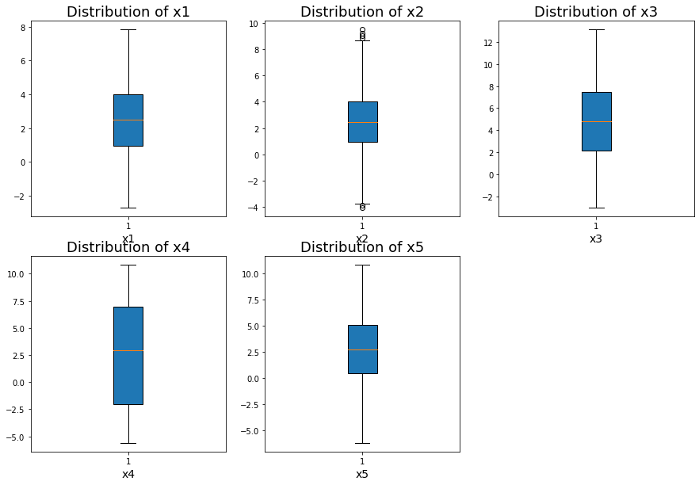

```python
figure = plt.figure(figsize=(15, 10))
axes = figure.add_subplot(2, 3, 1)

patch = axes.boxplot(df_syn["x1"], showfliers=True, patch_artist=True, zorder=1)
axes.set_title("Distribution of x1", fontsize = 18)
axes.set_xlabel("x1", fontsize = 14)

axes = figure.add_subplot(2, 3, 2)
patch = axes.boxplot(df_syn["x2"], showfliers=True, patch_artist=True, zorder=1)
axes.set_title("Distribution of x2", fontsize = 18)
axes.set_xlabel("x2", fontsize = 14)

axes = figure.add_subplot(2, 3, 3)
patch = axes.boxplot(df_syn["x3"], showfliers=True, patch_artist=True, zorder=1)
axes.set_title("Distribution of x3", fontsize = 18)
axes.set_xlabel("x3", fontsize = 14)

axes = figure.add_subplot(2, 3, 4)
patch = axes.boxplot(df_syn["x4"], showfliers=True, patch_artist=True, zorder=1)
axes.set_title("Distribution of x4", fontsize = 18)
axes.set_xlabel("x4", fontsize = 14)

axes = figure.add_subplot(2, 3, 5)
patch = axes.boxplot(df_syn["x5"], showfliers=True, patch_artist=True, zorder=1)
axes.set_title("Distribution of x5", fontsize = 18)
axes.set_xlabel("x5", fontsize = 14)

plt.show()
plt.close()
```

```python
def outlier_removal(data):
    """
    The function calculates the 0.01 percentile and 0.99 percentile
    It sets extreme vaues to the two percentiles base on whether the extreme values are
    high or low.
    """
    df = data.copy()
    for col in df.columns:
        if col=="class":
            df[col]=df[col]
        elif (((df[col].dtype)=='float64') | ((df[col].dtype)=='int64')):
            percentiles = df[col].quantile([0.1,0.9]).values

            df[col].loc[df[col] <= percentiles[0]] = percentiles[0]
            df[col].loc[df[col] >= percentiles[1]] = percentiles[1]
        else:
            df[col]=df[col]
    return df
```

```python
df_syn_filtered = outlier_removal(df_syn)
```

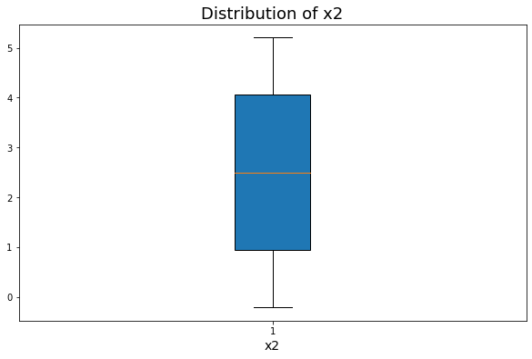

```python
figure = plt.figure(figsize=(10, 6))
axes   = figure.add_subplot(1, 1, 1)

axes.boxplot(df_syn_filtered["x2"], showfliers=True, patch_artist=True, zorder=1)

axes.set_title("Distribution of x2", fontsize = 18)

axes.set_xlabel("x2", fontsize = 14)

plt.show()
```

### Convert the string values for class into boolean

```python
def string_to_boolean(x):
    """
    This fucntion takes a column of the data, calculates the mean
    and set any number less than the mean to zero, else 1
    """
    coded = []
    for value in x:
        if value == "G":
            coded.append(1)
        if value == "H":
            coded.append(0)
    return coded

df_syn_filtered = df_syn_filtered.apply(lambda x: string_to_boolean(x) if x.name in ['class'] else x)
df_syn_filtered.sample(frac = 1).head(10)
```

|  | x1 | x2 | x3 | x4 | x5 | class |
| --- | --- | --- | --- | --- | --- | --- |
| 3131 | 0.261000 | 4.754365 | 1.885291 | 6.841333 | -0.957793 | 1 |
| 8350 | 4.830862 | -0.207068 | 8.197136 | -1.624564 | 5.374815 | 0 |
| 4129 | 2.175192 | 5.203998 | 2.478198 | 7.828824 | 1.214712 | 1 |
| 5832 | 4.652178 | 0.332251 | 5.703959 | -2.873622 | 4.241126 | 0 |
| 2691 | 0.229447 | 1.038476 | 1.752760 | 5.401182 | 0.204919 | 1 |
| 5706 | 4.830862 | -0.025366 | 6.930728 | -1.797983 | 6.490963 | 0 |
| 9752 | 3.547339 | 2.731696 | 8.158403 | -1.016700 | 5.637394 | 0 |
| 3391 | 0.471728 | 3.714008 | 4.433404 | 7.703242 | -0.781794 | 1 |
| 1416 | 1.011173 | 4.542392 | 3.306834 | 7.557417 | 0.734958 | 1 |
| 8991 | 3.797978 | 1.446428 | 7.618646 | -1.767009 | 4.988349 | 0 |

```python
df_syn_filtered["class"].unique()
```

```
array([1, 0], dtype=int64)
```

### Histogram distribution of the data

```python
df1_class0 = df_syn_filtered[df_syn_filtered["class"] ==0].reset_index(drop=True)
df1_class1 = df_syn_filtered[df_syn_filtered["class"] ==1].reset_index(drop=True)
```

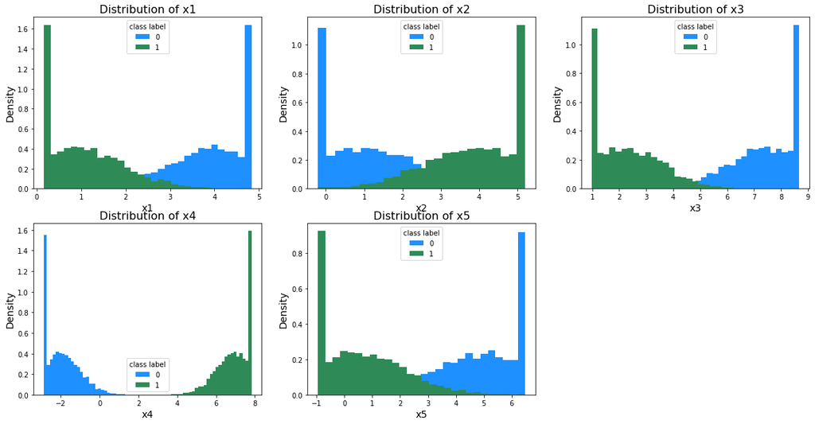

```python
figure = plt.figure(figsize=(20,10))
i = 1
for column in df1_class0.columns:
    if column == "class":
        continue
    else:
        ax = plt.subplot(2,3,i)
        ax.hist(df1_class0[column], bins="auto", density=True, color="DodgerBlue", label = "0")
        ax.hist(df1_class1[column], bins="auto", density=True, color="seagreen", label = "1")
        plt.title("Distribution of " + str(column), fontsize = 16)
        plt.ylabel( "Density", fontsize = 14)
        plt.xlabel( str(column), fontsize = 14)
        plt.legend(title = "class label")

    i = i+1
plt.show()
```

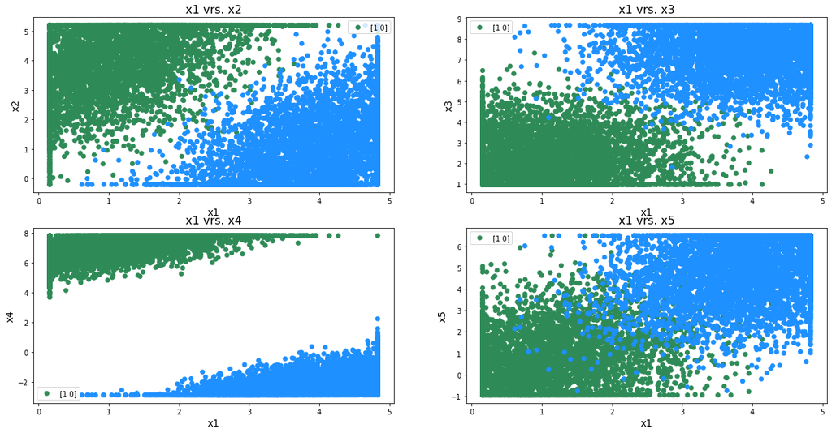

```python
figure = plt.figure(figsize=(20,10))
i = 1
for col in df_syn_filtered.columns:
    if ((col == "class") or (col == "x1")):
        continue
    axes = figure.add_subplot(2, 2, i)
    labels = [0, 1]
    colors = df_syn_filtered["class"].apply(lambda x: "DodgerBlue" if x ==0  else 'seagreen')
    axes.scatter(df_syn_filtered.x1, df_syn_filtered[col],  color = colors, label = df_syn_filtered["class"].unique())
    axes.set_title("x1 vrs. " + str(col),  fontsize  = 16)
    axes.set_xlabel( "x1",  fontsize  = 14)
    axes.set_ylabel(str(col),  fontsize  = 14)
    i = i+1
    axes.legend()
```

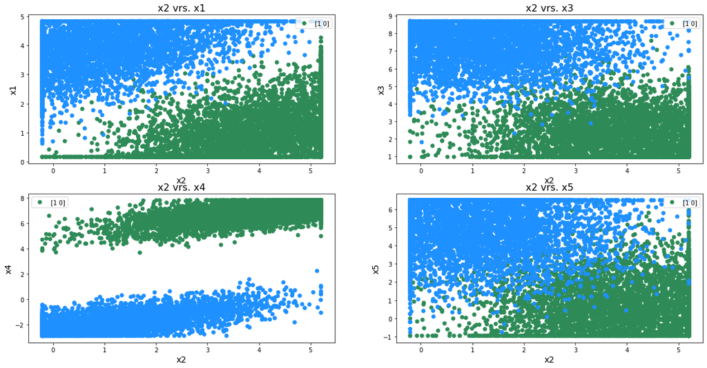

```python
figure = plt.figure(figsize=(20,10))
i = 1
for col in df_syn_filtered.columns:
    if ((col == "class") or (col == "x2")):
        continue
    axes = figure.add_subplot(2, 2, i)
    labels = [0, 1]
    colors = df_syn_filtered["class"].apply(lambda x: "DodgerBlue" if x ==0  else 'seagreen')
    axes.scatter(df_syn_filtered.x2, df_syn_filtered[col],  color = colors, label = df_syn_filtered["class"].unique())
    axes.set_title("x2 vrs. " + str(col),  fontsize  = 16)
    axes.set_xlabel( "x2",  fontsize  = 14)
    axes.set_ylabel(str(col),  fontsize  = 14)
    i = i+1
    axes.legend()
```

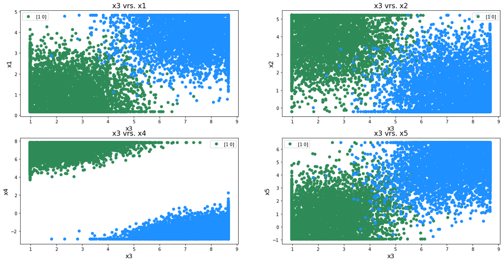

```python
figure = plt.figure(figsize=(20,10))
i = 1
for col in df_syn_filtered.columns:
    if ((col == "class") or (col == "x3")):
        continue
    axes = figure.add_subplot(2, 2, i)
    labels = [0, 1]
    colors = df_syn_filtered["class"].apply(lambda x: "DodgerBlue" if x ==0  else 'seagreen')
    axes.scatter(df_syn_filtered.x3, df_syn_filtered[col],  color = colors, label = df_syn_filtered["class"].unique())
    axes.set_title("x3 vrs. " + str(col),  fontsize  = 16)
    axes.set_xlabel( "x3",  fontsize  = 14)
    axes.set_ylabel(str(col),  fontsize  = 14)
    i = i+1
    axes.legend()
```

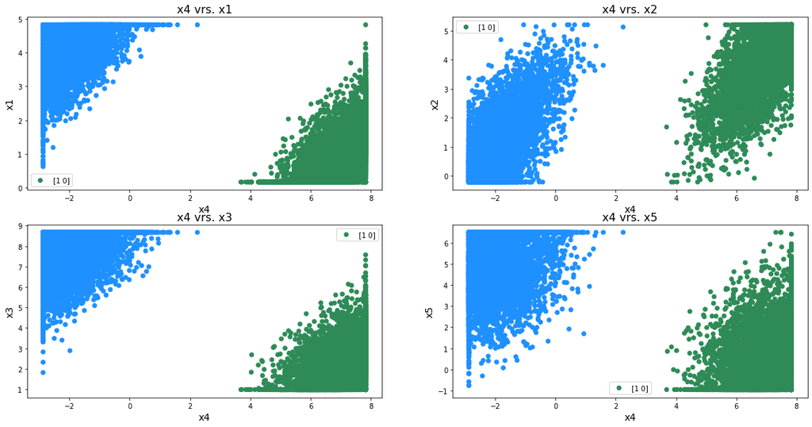

```python
figure = plt.figure(figsize=(20,10))
i = 1
for col in df_syn_filtered.columns:
    if ((col == "class") or (col == "x4")):
        continue
    axes = figure.add_subplot(2, 2, i)
    labels = [0, 1]
    colors = df_syn_filtered["class"].apply(lambda x: "DodgerBlue" if x ==0  else 'seagreen')
    axes.scatter(df_syn_filtered.x4, df_syn_filtered[col],  color = colors, label = df_syn_filtered["class"].unique())
    axes.set_title("x4 vrs. " + str(col),  fontsize  = 16)
    axes.set_xlabel( "x4",  fontsize  = 14)
    axes.set_ylabel(str(col),  fontsize  = 14)
    i = i+1
    axes.legend()
```

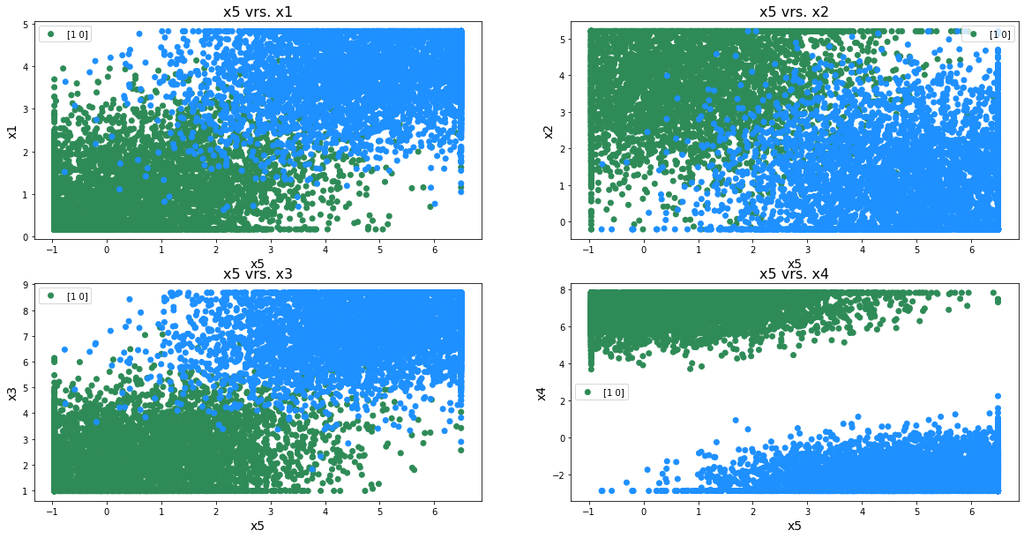

```python
figure = plt.figure(figsize=(20,10))
i = 1
for col in df_syn_filtered.columns:
    if ((col == "class") or (col == "x5")):
        continue
    axes = figure.add_subplot(2, 2, i)
    labels = [0, 1]
    colors = df_syn_filtered["class"].apply(lambda x: "DodgerBlue" if x ==0  else 'seagreen')
    axes.scatter(df_syn_filtered.x5, df_syn_filtered[col],  color = colors, label = df_syn_filtered["class"].unique())
    axes.set_title("x5 vrs. " + str(col),  fontsize  = 16)
    axes.set_xlabel( "x5",  fontsize  = 14)
    axes.set_ylabel(str(col),  fontsize  = 14)
    i = i+1
    axes.legend()
```

### SPAM E-mail Data

```python
file2 = r"spambase_data.csv" #data file

#create headers for the data
headers = ["x1", "x2", "x3", "x4", "x5","x6", "x7", "x8", "x9", "x10", "x11", "x12", "x13", "x14", "x15", "x16",
           "x17", "x18", "x19", "x20", "x21", "x22", "x23", "x24", "x25", "x26", "x27", "x28", "x29", "x30", "x31",
           "x32", "x33", "x34", "35", "36", "37", "38", "x39", "x40", "x41", "x42", "x43", "x44", "x45", "x46", "x47",
           "x48", "x49", "x50", "x51", "x52", "x53", "x54", "x55", "x56", "x57", "class"]

#read data with pandas read csv function
df_spam = pd.read_csv(file2, sep="\s*,\s*", names = headers, engine='python')

#shuffle the data
df_spam.sample(frac = 1).head(5)
```

|  | x1 | x2 | x3 | x4 | x5 | x6 | x7 | x8 | x9 | x10 | ... | x49 | x50 | x51 | x52 | x53 | x54 | x55 | x56 | x57 | class |
| --- | --- | --- | --- | --- | --- | --- | --- | --- | --- | --- | --- | --- | --- | --- | --- | --- | --- | --- | --- | --- | --- |
| 1204 | 0.000000 | 0.560000 | 0.560000 | 0.000000 | 2.250000 | 0.000000 | 0.560000 | 0.000000 | 0.000000 | 0.000000 | ... | 0.000000 | 0.260000 | 0.000000 | 1.217000 | 0.347000 | 0.000000 | 5.105000 | 140 | 194 | 1 |
| 1384 | 0.000000 | 0.000000 | 0.000000 | 0.000000 | 0.000000 | 0.000000 | 0.000000 | 0.000000 | 0.930000 | 0.000000 | ... | 0.000000 | 0.140000 | 0.000000 | 0.561000 | 0.000000 | 0.000000 | 2.166000 | 23 | 65 | 1 |
| 2338 | 0.400000 | 0.000000 | 0.400000 | 0.000000 | 0.000000 | 0.000000 | 0.000000 | 0.000000 | 0.000000 | 0.000000 | ... | 0.000000 | 0.000000 | 0.000000 | 0.000000 | 0.000000 | 0.000000 | 1.148000 | 3 | 31 | 0 |
| 1063 | 0.000000 | 0.000000 | 0.000000 | 0.000000 | 0.000000 | 0.000000 | 1.780000 | 0.000000 | 0.000000 | 1.780000 | ... | 0.000000 | 0.000000 | 0.000000 | 0.544000 | 0.000000 | 0.000000 | 1.777000 | 5 | 16 | 1 |
| 2207 | 0.000000 | 0.000000 | 0.000000 | 0.000000 | 0.000000 | 0.000000 | 0.000000 | 0.000000 | 0.000000 | 0.000000 | ... | 0.000000 | 0.000000 | 0.000000 | 0.000000 | 0.000000 | 0.000000 | 1.000000 | 1 | 3 | 0 |

5 rows × 58 columns

#### Check for missing data

```python
df_spam.isnull().values.any()
```

```
False
```

No missing data

#### Data type

```python
df_spam.info()
```

```
<class 'pandas.core.frame.DataFrame'>
RangeIndex: 4601 entries, 0 to 4600
Data columns (total 58 columns):
 #   Column  Non-Null Count  Dtype
---  ------  --------------  -----
 0   x1      4601 non-null   float64
 1   x2      4601 non-null   float64
 2   x3      4601 non-null   float64
 3   x4      4601 non-null   float64
 4   x5      4601 non-null   float64
 5   x6      4601 non-null   float64
 6   x7      4601 non-null   float64
 7   x8      4601 non-null   float64
 8   x9      4601 non-null   float64
 9   x10     4601 non-null   float64
```

[output cut: 50 more lines]

```python
df_spam.describe()
```

|  | x1 | x2 | x3 | x4 | x5 | x6 | x7 | x8 | x9 | x10 | ... | x49 | x50 | x51 | x52 | x53 | x54 | x55 | x56 | x57 | class |
| --- | --- | --- | --- | --- | --- | --- | --- | --- | --- | --- | --- | --- | --- | --- | --- | --- | --- | --- | --- | --- | --- |
| count | 4,601.000000 | 4,601.000000 | 4,601.000000 | 4,601.000000 | 4,601.000000 | 4,601.000000 | 4,601.000000 | 4,601.000000 | 4,601.000000 | 4,601.000000 | ... | 4,601.000000 | 4,601.000000 | 4,601.000000 | 4,601.000000 | 4,601.000000 | 4,601.000000 | 4,601.000000 | 4,601.000000 | 4,601.000000 | 4,601.000000 |
| mean | 0.104553 | 0.213015 | 0.280656 | 0.065425 | 0.312223 | 0.095901 | 0.114208 | 0.105295 | 0.090067 | 0.239413 | ... | 0.038575 | 0.139030 | 0.016976 | 0.269071 | 0.075811 | 0.044238 | 5.191515 | 52.172789 | 283.289285 | 0.394045 |
| std | 0.305358 | 1.290575 | 0.504143 | 1.395151 | 0.672513 | 0.273824 | 0.391441 | 0.401071 | 0.278616 | 0.644755 | ... | 0.243471 | 0.270355 | 0.109394 | 0.815672 | 0.245882 | 0.429342 | 31.729449 | 194.891310 | 606.347851 | 0.488698 |
| min | 0.000000 | 0.000000 | 0.000000 | 0.000000 | 0.000000 | 0.000000 | 0.000000 | 0.000000 | 0.000000 | 0.000000 | ... | 0.000000 | 0.000000 | 0.000000 | 0.000000 | 0.000000 | 0.000000 | 1.000000 | 1.000000 | 1.000000 | 0.000000 |
| 25% | 0.000000 | 0.000000 | 0.000000 | 0.000000 | 0.000000 | 0.000000 | 0.000000 | 0.000000 | 0.000000 | 0.000000 | ... | 0.000000 | 0.000000 | 0.000000 | 0.000000 | 0.000000 | 0.000000 | 1.588000 | 6.000000 | 35.000000 | 0.000000 |
| 50% | 0.000000 | 0.000000 | 0.000000 | 0.000000 | 0.000000 | 0.000000 | 0.000000 | 0.000000 | 0.000000 | 0.000000 | ... | 0.000000 | 0.065000 | 0.000000 | 0.000000 | 0.000000 | 0.000000 | 2.276000 | 15.000000 | 95.000000 | 0.000000 |
| 75% | 0.000000 | 0.000000 | 0.420000 | 0.000000 | 0.380000 | 0.000000 | 0.000000 | 0.000000 | 0.000000 | 0.160000 | ... | 0.000000 | 0.188000 | 0.000000 | 0.315000 | 0.052000 | 0.000000 | 3.706000 | 43.000000 | 266.000000 | 1.000000 |
| max | 4.540000 | 14.280000 | 5.100000 | 42.810000 | 10.000000 | 5.880000 | 7.270000 | 11.110000 | 5.260000 | 18.180000 | ... | 4.385000 | 9.752000 | 4.081000 | 32.478000 | 6.003000 | 19.829000 | 1,102.500000 | 9,989.000000 | 15,841.000000 | 1.000000 |

8 rows × 58 columns

Quite some interesting data set. Most of the data points are zero.

#### Check for outliers using boxplot.

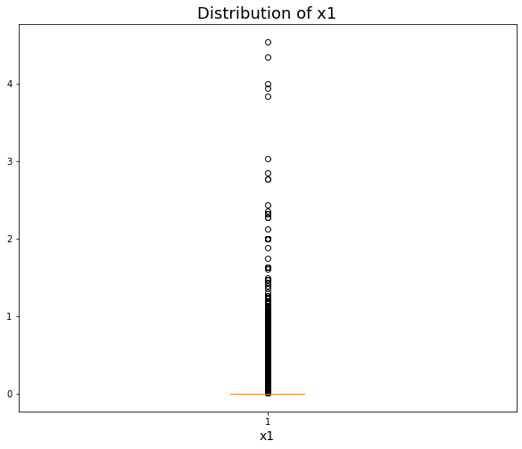

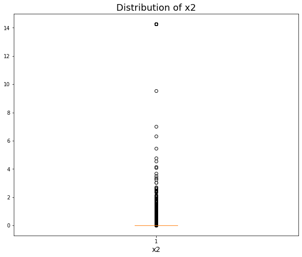

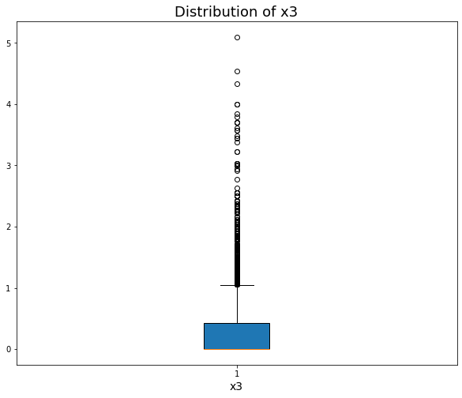

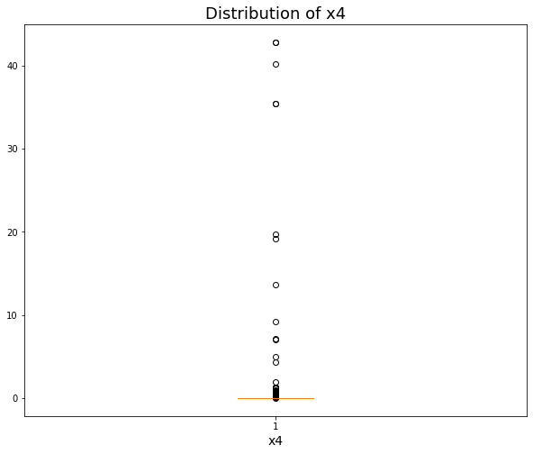

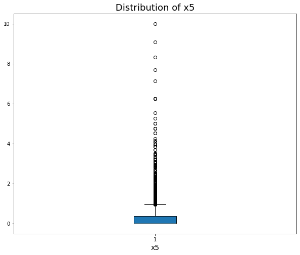

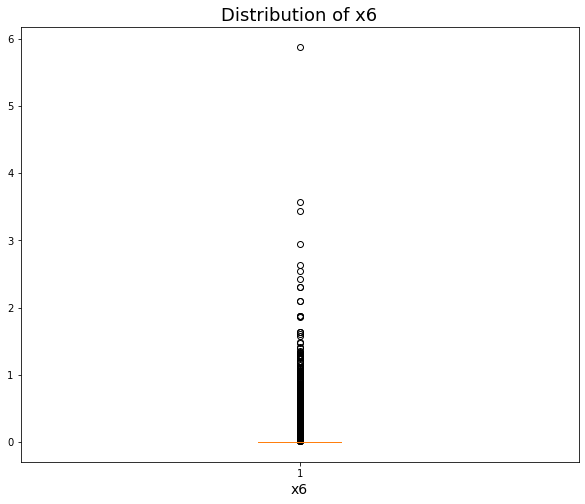

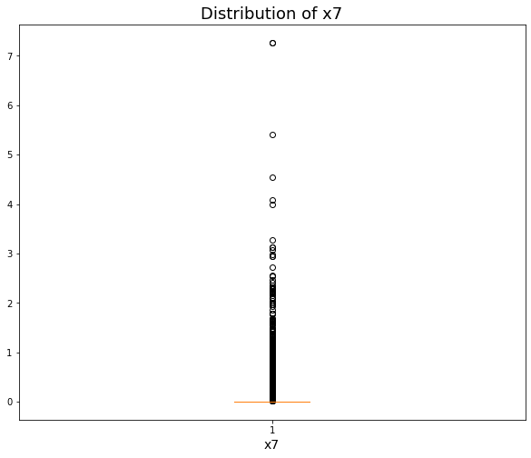

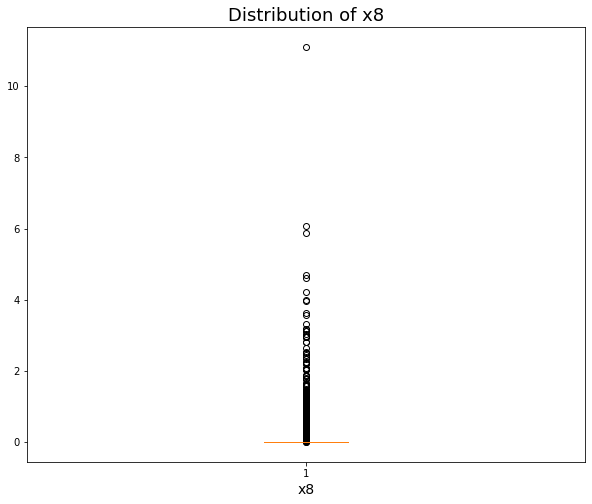

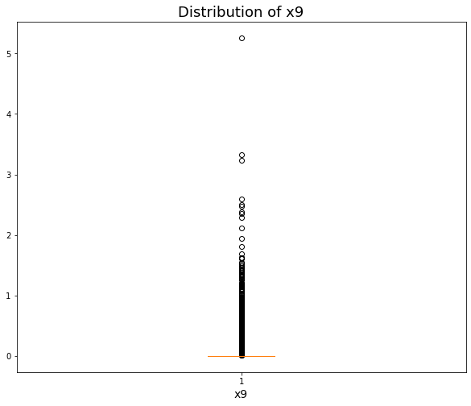

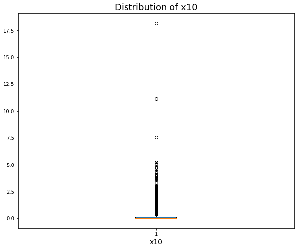

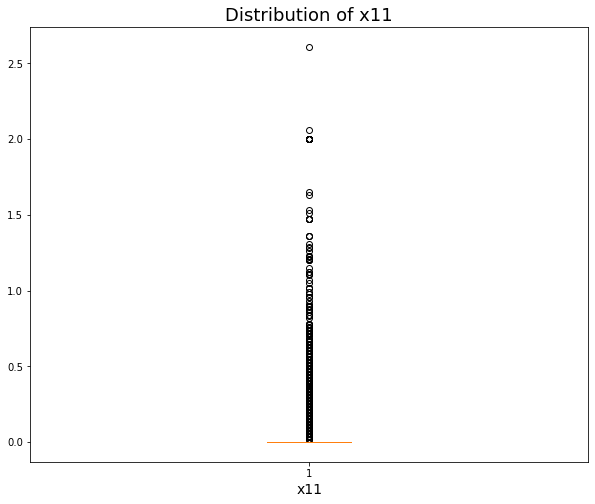

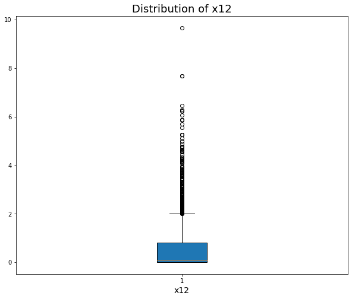

[46 more figures not shown]

```python
for col in df_spam.columns:
    figure = plt.figure(figsize=(10, 8))
    axes = figure.add_subplot(1, 1, 1)

    patch = axes.boxplot(df_spam[col], showfliers=True, patch_artist=True, zorder=1)
    axes.set_title("Distribution of " + str(col), fontsize = 18)
    axes.set_xlabel(str(col), fontsize = 14)
    plt.show()
```

### 3. Standardize the data and remove outliers

Scale the feature to have mean of 0 and standard deviation of 1.We will not scale the class feature

```python
#synthetic data
def feature_scaling(df):
    for column in df.columns:
        df[column] = (df[column] - df[column].mean())/df[column].std()
    return df

sub = df_syn_filtered.drop("class", axis=1)

df_stand1 = feature_scaling(sub)

df_stand1["class"] = df_syn_filtered["class"]
```

```python
df_stand1.sample(frac = 1).head(10)
```

|  | x1 | x2 | x3 | x4 | x5 | class |
| --- | --- | --- | --- | --- | --- | --- |
| 4382 | -1.436395 | 1.002807 | -1.337474 | 0.804288 | -0.655344 | 1 |
| 4397 | -0.866133 | 1.364036 | -0.602866 | 1.178210 | -0.586108 | 1 |
| 9154 | 0.591091 | -1.306581 | 0.427899 | -1.201300 | 0.443325 | 0 |
| 6758 | -0.270476 | -1.505373 | 0.165371 | -1.201300 | 0.911719 | 0 |
| 8046 | 0.456042 | -0.799212 | 1.240872 | -0.994879 | 0.434556 | 0 |
| 7991 | 1.081669 | -1.505373 | 0.980028 | -1.099663 | 0.936093 | 0 |
| 703 | -0.628099 | 0.834461 | -0.644457 | 1.154505 | -0.973983 | 1 |
| 2870 | -1.065397 | 1.393734 | -1.396852 | 0.944077 | -1.467601 | 1 |
| 8676 | 1.385603 | -1.176966 | 1.160648 | -0.915955 | 1.236490 | 0 |
| 1301 | 0.031837 | 1.507112 | -0.335461 | 1.194825 | -0.524881 | 1 |

```python
#mean of the synthetic data
df_stand1.mean()
```

```
x1      -0.000000
x2      -0.000000
x3      -0.000000
x4       0.000000
x5      -0.000000
class    0.500000
dtype: float64
```

```python
#sigma of the synthetic data
df_stand1.std()
```

```
x1      1.000000
x2      1.000000
x3      1.000000
x4      1.000000
x5      1.000000
class   0.500025
dtype: float64
```

#### Spam email data

```python
#spam email data
sub = df_spam.drop("class", axis=1)

df_stand2 = feature_scaling(sub)

df_stand2["class"] = df_spam["class"]
```

```python
df_stand2.sample(frac = 1).head(10)
```

|  | x1 | x2 | x3 | x4 | x5 | x6 | x7 | x8 | x9 | x10 | ... | x49 | x50 | x51 | x52 | x53 | x54 | x55 | x56 | x57 | class |
| --- | --- | --- | --- | --- | --- | --- | --- | --- | --- | --- | --- | --- | --- | --- | --- | --- | --- | --- | --- | --- | --- |
| 2822 | -0.342396 | -0.165054 | -0.556700 | -0.046894 | -0.464264 | -0.350228 | -0.291762 | -0.262533 | -0.323267 | -0.371324 | ... | -0.158436 | 0.284698 | -0.155181 | -0.277159 | -0.308321 | -0.103037 | -0.122647 | -0.231785 | -0.381447 | 0 |
| 2567 | -0.342396 | -0.165054 | -0.556700 | -0.046894 | -0.464264 | -0.350228 | -0.291762 | -0.262533 | -0.323267 | 1.474337 | ... | -0.158436 | 1.782726 | -0.155181 | -0.329876 | -0.308321 | -0.103037 | -0.081140 | -0.211260 | -0.320425 | 0 |
| 1592 | 2.179237 | 0.129388 | 0.970645 | -0.046894 | -0.464264 | 1.731400 | -0.291762 | 1.158660 | 3.804280 | 1.706984 | ... | -0.047540 | -0.414382 | -0.155181 | 0.207104 | 0.468474 | 0.022737 | 0.297121 | 2.426107 | 1.051724 | 1 |
| 2104 | -0.342396 | -0.165054 | -0.556700 | -0.046894 | -0.464264 | -0.350228 | -0.291762 | -0.262533 | -0.323267 | -0.371324 | ... | -0.158436 | -0.514251 | -0.155181 | 0.283115 | -0.308321 | -0.103037 | -0.115146 | -0.226653 | -0.434222 | 0 |
| 1137 | 0.214328 | -0.165054 | -0.398015 | -0.046894 | 0.160260 | -0.058070 | -0.087389 | 0.784662 | -0.036134 | -0.247246 | ... | -0.158436 | -0.199850 | 0.100774 | -0.208504 | -0.251384 | -0.103037 | -0.035346 | -0.021411 | 0.479445 | 1 |
| 3472 | -0.342396 | -0.165054 | -0.556700 | -0.046894 | -0.464264 | -0.350228 | -0.291762 | -0.262533 | -0.323267 | -0.371324 | ... | 0.367293 | -0.514251 | 1.014900 | -0.329876 | -0.308321 | -0.103037 | -0.113318 | -0.206129 | -0.330321 | 0 |
| 3020 | -0.342396 | -0.165054 | -0.556700 | -0.046894 | -0.464264 | -0.350228 | -0.291762 | -0.262533 | -0.323267 | -0.371324 | ... | -0.158436 | 1.287082 | -0.155181 | -0.329876 | -0.308321 | -0.103037 | -0.083787 | -0.211260 | -0.404536 | 0 |
| 262 | -0.342396 | -0.165054 | 0.673110 | -0.046894 | 1.379567 | 1.913999 | -0.291762 | -0.262533 | -0.323267 | -0.371324 | ... | -0.158436 | -0.196151 | -0.155181 | -0.277159 | -0.308321 | -0.103037 | -0.108748 | -0.195867 | -0.211577 | 1 |
| 964 | -0.342396 | -0.165054 | 2.081441 | -0.046894 | 0.517130 | -0.350228 | -0.291762 | -0.262533 | -0.323267 | -0.371324 | ... | -0.158436 | -0.514251 | -0.155181 | 0.105348 | 0.171584 | -0.103037 | -0.090658 | -0.206129 | -0.249509 | 1 |
| 971 | 2.768710 | -0.165054 | -0.100480 | -0.046894 | -0.122263 | 0.489727 | 0.295810 | -0.262533 | -0.323267 | -0.014600 | ... | -0.158436 | -0.514251 | -0.155181 | -0.038092 | -0.308321 | -0.103037 | -0.063270 | -0.072722 | -0.068095 | 1 |

10 rows × 58 columns

```python
df_stand2.describe()
```

|  | x1 | x2 | x3 | x4 | x5 | x6 | x7 | x8 | x9 | x10 | ... | x49 | x50 | x51 | x52 | x53 | x54 | x55 | x56 | x57 | class |
| --- | --- | --- | --- | --- | --- | --- | --- | --- | --- | --- | --- | --- | --- | --- | --- | --- | --- | --- | --- | --- | --- |
| count | 4,601.000000 | 4,601.000000 | 4,601.000000 | 4,601.000000 | 4,601.000000 | 4,601.000000 | 4,601.000000 | 4,601.000000 | 4,601.000000 | 4,601.000000 | ... | 4,601.000000 | 4,601.000000 | 4,601.000000 | 4,601.000000 | 4,601.000000 | 4,601.000000 | 4,601.000000 | 4,601.000000 | 4,601.000000 | 4,601.000000 |
| mean | 0.000000 | 0.000000 | 0.000000 | 0.000000 | 0.000000 | 0.000000 | 0.000000 | -0.000000 | 0.000000 | 0.000000 | ... | 0.000000 | -0.000000 | -0.000000 | 0.000000 | 0.000000 | 0.000000 | 0.000000 | 0.000000 | 0.000000 | 0.394045 |
| std | 1.000000 | 1.000000 | 1.000000 | 1.000000 | 1.000000 | 1.000000 | 1.000000 | 1.000000 | 1.000000 | 1.000000 | ... | 1.000000 | 1.000000 | 1.000000 | 1.000000 | 1.000000 | 1.000000 | 1.000000 | 1.000000 | 1.000000 | 0.488698 |
| min | -0.342396 | -0.165054 | -0.556700 | -0.046894 | -0.464264 | -0.350228 | -0.291762 | -0.262533 | -0.323267 | -0.371324 | ... | -0.158436 | -0.514251 | -0.155181 | -0.329876 | -0.308321 | -0.103037 | -0.132102 | -0.262571 | -0.465557 | 0.000000 |
| 25% | -0.342396 | -0.165054 | -0.556700 | -0.046894 | -0.464264 | -0.350228 | -0.291762 | -0.262533 | -0.323267 | -0.371324 | ... | -0.158436 | -0.514251 | -0.155181 | -0.329876 | -0.308321 | -0.103037 | -0.113570 | -0.236916 | -0.409483 | 0.000000 |
| 50% | -0.342396 | -0.165054 | -0.556700 | -0.046894 | -0.464264 | -0.350228 | -0.291762 | -0.262533 | -0.323267 | -0.371324 | ... | -0.158436 | -0.273826 | -0.155181 | -0.329876 | -0.308321 | -0.103037 | -0.091887 | -0.190736 | -0.310530 | 0.000000 |
| 75% | -0.342396 | -0.165054 | 0.276397 | -0.046894 | 0.100781 | -0.350228 | -0.291762 | -0.262533 | -0.323267 | -0.123168 | ... | -0.158436 | 0.181130 | -0.155181 | 0.056308 | -0.096838 | -0.103037 | -0.046818 | -0.047066 | -0.028514 | 1.000000 |
| max | 14.525419 | 10.899780 | 9.559480 | 30.637948 | 14.405342 | 21.123413 | 18.280624 | 27.438267 | 18.555773 | 27.825415 | ... | 17.851898 | 35.556791 | 37.150283 | 39.487617 | 24.105827 | 46.081580 | 34.583282 | 50.986507 | 25.658062 | 1.000000 |

8 rows × 58 columns

There are quite a lot of outliers in this data; the 75th percentile is way lower than the max values in the data.

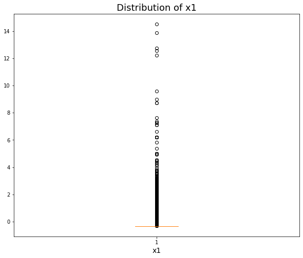

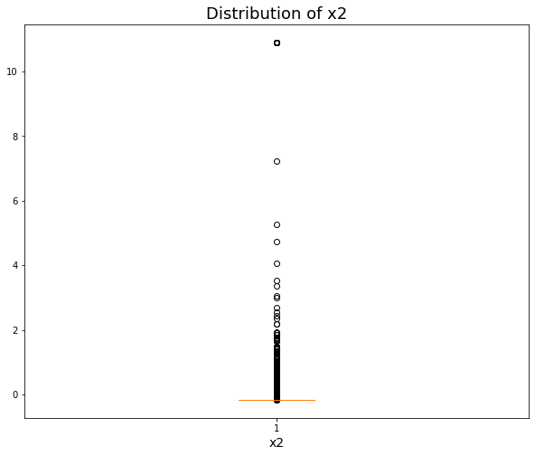

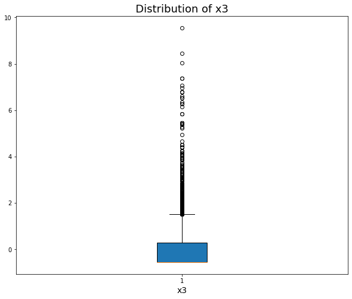

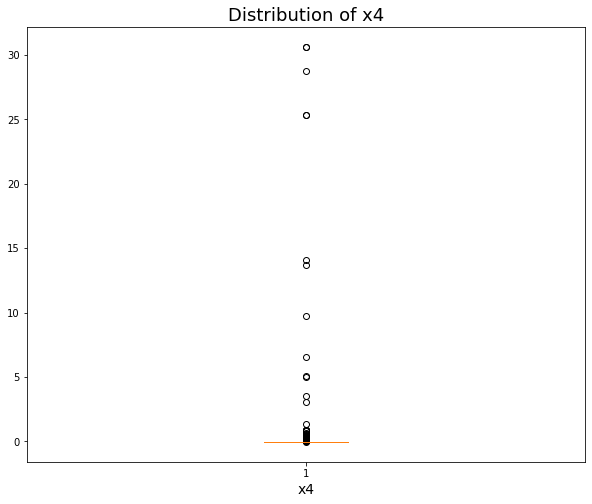

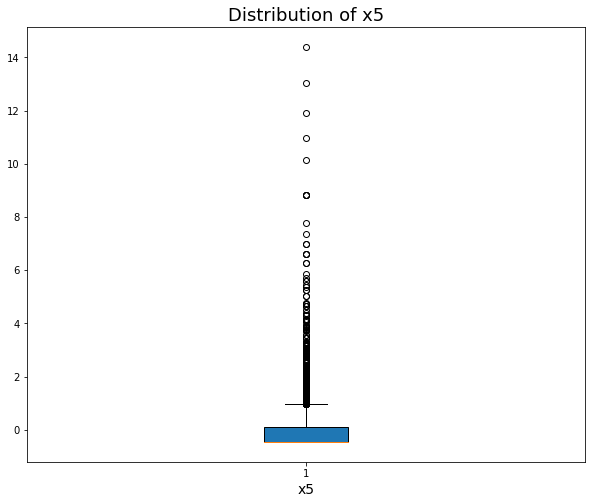

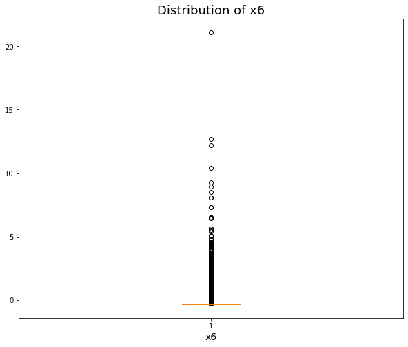

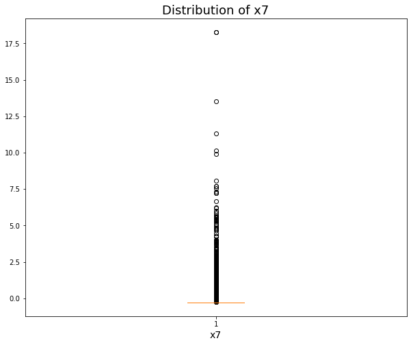

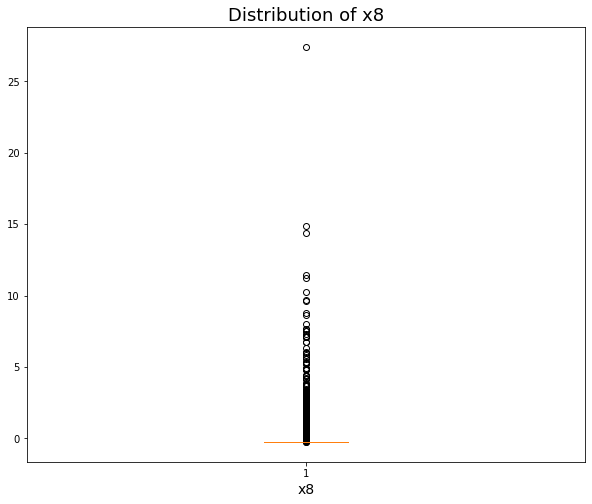

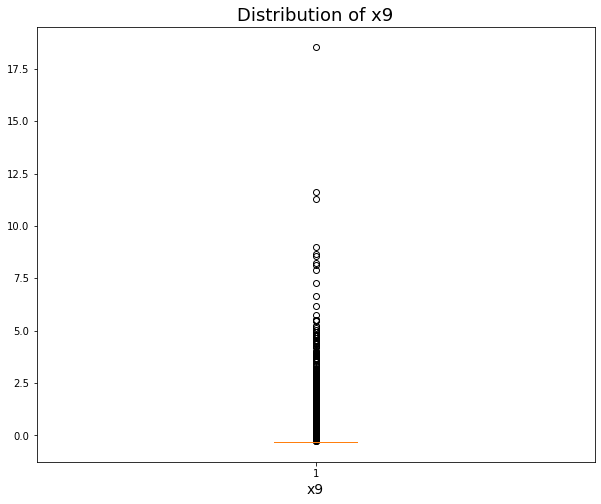

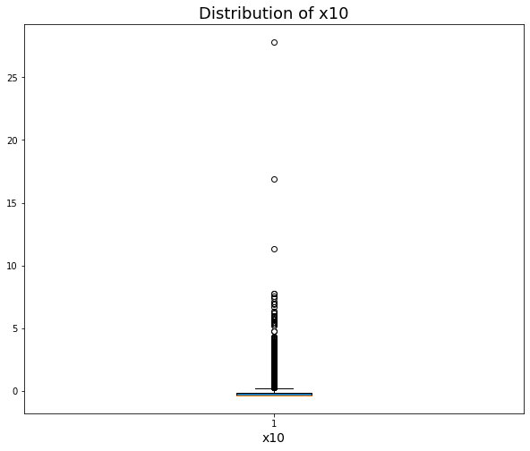

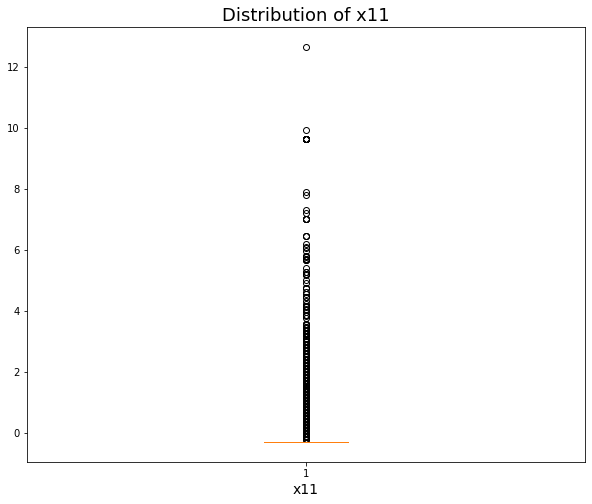

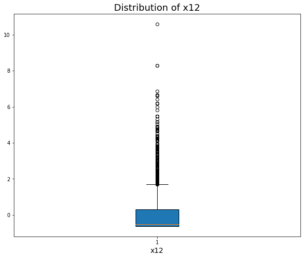

[46 more figures not shown]

```python
for col in df_stand2.columns:
    figure = plt.figure(figsize=(10, 8))
    axes = figure.add_subplot(1, 1, 1)

    patch = axes.boxplot(df_stand2[col], showfliers=True, patch_artist=True, zorder=1)
    axes.set_title("Distribution of " + str(col), fontsize = 18)
    axes.set_xlabel(str(col), fontsize = 14)
    plt.show()
```

### 4. Set up your test and training sets from the provided data. Specifically, split the data into two groups randomly where 2/3 of the data will be used for training and 1/3 will be used for testing.

#### Synthetic data

```python
fraction = 2/3
seed = 1600307489

#randomly sample the training data
train1 = df_stand1.sample(frac = fraction, random_state=seed, axis=0 )

#get test data by removing the training data from its total data set
test1 = df_stand1[~df_stand1.index.isin(train1.index)].reset_index(drop=True)

train1 = train1.reset_index(drop=True)
```

```python
X_train1 = train1.drop("class", axis = 1).astype(float)
X_test1  = test1.drop("class", axis = 1).astype(float)

y_train1 = train1["class"]
y_test1  = test1["class"]
```

```python
X_train1.shape[0]
```

```
6667
```

#### spam data

```python
fraction = 2/3
seed = 1600307489

#randomly sample the training data
train2 = df_stand2.sample(frac = fraction, random_state=seed, axis=0 )

#get test data by removing the training data from its total data set
test2 = df_stand2[~df_stand2.index.isin(train2.index)].reset_index(drop=True)

train2 = train2.reset_index(drop=True)
```

```python
X_train2 = train2.drop("class", axis = 1).astype(float)
X_test2  = test2.drop("class", axis = 1).astype(float)

y_train2 = train2["class"]
y_test2  = test2["class"]
```

```python
X_train2.shape[0]
```

```
3067
```

## 5. Feature selection - Stepwise forward selection

The stepwise_forward_selection function takes five inputs: the training X data set, test X data set, training y, test y, and threshold. The default threshold is 0.0001 error to decide optimal model.

first iterates through allthe features to find the feature that gives best model score metric. Keep the best found feature Perform pair-wise iteration of the best feature with all features to find the best two features iterate to find the best 3 features, so on. In each iteration, check model score metric against previous score metric. If the difference in core is not greater than the threshold, return all best features found.

@return results data frame

```python
from  classification_model_selection import ModelSelctions as ms
```

#### Synthetic data

```python
feature_sel1 =  ms.stepwise_forward_selection(X_train1, X_test1, y_train1, y_test1, threshold = 0.0001)
```

```
features count = 1
best feature = x4
score with feature added = 1.0
error with feature added = 0.0
```

```python
feature_sel1
```

|  | iter_features | accuracy | feature_count | best_features | error_rate |
| --- | --- | --- | --- | --- | --- |
| 0 | ['x4'] | 1.000000 | 1 | x4 | 0.000000 |

We have 1 selected feature for the synthetic data

#### Spam email data

```python
feature_sel2 =  ms.stepwise_forward_selection(X_train2, X_test2, y_train2, y_test2, threshold = 0.0001)
```

```
features count = 1
best feature = x53
score with feature added = 0.7816166883963495
error with feature added = 0.21838331160365054
features count = 2
best feature = x25
score with feature added = 0.8285528031290743
error with feature added = 0.1714471968709257
features count = 3
best feature = x7
score with feature added = 0.8500651890482399
error with feature added = 0.1499348109517601
features count = 4
best feature = x39
score with feature added = 0.8748370273794003
error with feature added = 0.12516297262059972
features count = 5
best feature = x16
score with feature added = 0.8852672750977836
error with feature added = 0.11473272490221642
features count = 6
best feature = x52
score with feature added = 0.8956975228161669
error with feature added = 0.10430247718383312
```

```python
feature_sel2
```

|  | iter_features | accuracy | feature_count | best_features | error_rate |
| --- | --- | --- | --- | --- | --- |
| 0 | ['x53'] | 0.781617 | 1 | x53 | 0.218383 |
| 1 | ['x53', 'x25'] | 0.828553 | 2 | x25 | 0.171447 |
| 2 | ['x53', 'x25', 'x7'] | 0.850065 | 3 | x7 | 0.149935 |
| 3 | ['x53', 'x25', 'x7', 'x39'] | 0.874837 | 4 | x39 | 0.125163 |
| 4 | ['x53', 'x25', 'x7', 'x39', 'x16'] | 0.885267 | 5 | x16 | 0.114733 |
| 5 | ['x53', 'x25', 'x7', 'x39', 'x16', 'x52'] | 0.895698 | 6 | x52 | 0.104302 |

We have 6 selected features for the spam email data

### 6.1. Naive Bayes Claifficantion

```python
from  naive_bayes_algorithm import Naive_Bayes_Classifier

from classification_models_performance import Model_Performance
```

#### Synthetic data

```python
nb_model=Naive_Bayes_Classifier()
#X_train1_array = np.array(X_train1[["x1","x4"]])
#X_test1_array  = np.array(X_test1[["x1","x4"]])

X_train1_array = np.array(X_train1[["x1","x4"]])
X_test1_array  = np.array(X_test1[["x1","x4"]])

y_train1_array = y_train1
y_test1_array  = y_test1

#fit the model
nb_model.fit(X_train1_array,y_train1_array)

#predict the data class
nb_results1=nb_model.predict(X_test1_array)

#add the actuals to our results data set
nb_results1["y_actual"] = y_test1_array

#calculate model accuracy
Model_Performance.scores(nb_results1)
```

```
{'accuracy': 1.0,
 'error_rate': 0.0,
 'RMS': 0.0,
 'sensitivity': 1.0,
 'precision': 1.0,
 'specificity': 1.0,
 'F_1': 1.0}
```

#### Spam email data

```python
nb_model=Naive_Bayes_Classifier()
X_train2_array = np.array(X_train2[['x53', 'x25', 'x7', 'x39', 'x16', 'x52']])
X_test2_array  = np.array(X_test2[['x53', 'x25', 'x7', 'x39', 'x16', 'x52']])

y_train2_array = y_train2
y_test2_array  = y_test2

#fit the model
nb_model.fit(X_train2_array,y_train2_array)

#predict the data class
nb_results2=nb_model.predict(X_test2_array)

#add the actuals to our results data set
nb_results2["y_actual"] = y_test2_array

#calculate model accuracy
Model_Performance.scores(nb_results2)
```

```
{'accuracy': 0.8956975228161669,
 'error_rate': 0.10430247718383312,
 'RMS': 0.3229589403992915,
 'sensitivity': 0.8120689655172414,
 'precision': 0.9022988505747126,
 'specificity': 0.9465408805031447,
 'F_1': 0.8548094373865699}
```

## 6.2. Write the K-means clustering algorithm

```python
def initial_centers(X, k):
    """
    Sample k unique data points from the data set to use as the intial
    means/centers/centroids of the mixture distributions.
    X: numpy array of the data set with N observations and D features/dimension
    k: Number of means to choose
    @Return array of k number means with size k : D
    """
    import random
    sample_size = X.shape[0]
    sample_id = random.sample(range(0, sample_size), k)

    means = [tuple(X[id]) for id in sample_id]
    unique_means = list(set(means))

    number_of_unique_means = len(unique_means)

    while number_of_unique_means < k:
        new_sample_id = random.sample(range(0, sample_size), k - number_of_unique_means)
        new_means = [tuple(X[id]) for id in new_sample_id]
        unique_means = list(set(unique_means + new_means))

        number_of_unique_means = len(unique_means)

    return np.array(unique_means)

def euclidean_distance(X, centers, squared=False):
    """
    Calculate the distance between data and the centers
    ----------
    X : np.array(N, D)

    Centers : np.array
        shape should be (k, D)
    N = number of rows in the data
    D = number of columns in the data (number of features)
    k = number of centers chosen
    @Return
    -------
    Distance : np.array(N, k)
    This is the distance matrix for each data point fron the centers
    """
    if X is None or centers is None:
        raise ValueError( "The 'data' and 'centers' must be assigned a non-null reference to numpy array")

    if X.shape[1] != centers.shape[1]:
        raise ValueError( "the number columns in data and number of columns in centers must be the same")

    N, k = X.shape[0], centers.shape[0]

    X_sq = (X*X).sum(axis=1).reshape((N,1))*np.ones(shape=(1,k))

    centers_sq = (centers*centers).sum(axis=1)*np.ones(shape=(N,1))

    squared_distance =  X_sq + centers_sq -2*X.dot(centers.T)

    if squared == False:
        zero_mask = np.less(squared_distance, 0.0)

        squared_distance[zero_mask] = 0.0

        return np.sqrt(squared_distance)

    return squared_distance

def expectation(X, centers, distance_metric):
    """
    This function finds the centers and assign each data point to a center
    based on how close it is to the center
    ----------
    X : np.array(N, D)

    centers : np.array(k, D)
        shape should be (K, D)
    N = number of rows in the data
    D = number of columns in the data (number of features)
    k = number of centers chosen

    distance_metric: the function to calculate data point distance from the centers.
                       Takes X(N, D) and centers(k, D) and return matrix(N, k)
    @Returns:
        cluster of data and their labels
    """

    k = centers.shape[0]

    clusters = {}

    distances = distance_metric(X, centers) #calculate distance from centers

    min_distances = np.argmin(distances, axis=1) #get index of min distance

    for i in range(k):
        clusters[i] = [] #initialize list to store clusters

    for data_idx, cluster_idx in enumerate(min_distances):

        clusters[cluster_idx].append(X[data_idx])

    return clusters

def maximization(X, k, distance_function, threshold=0):
    """
    This optimization function finds the centers that optimize the clustering (minimized within cluster distance)
    X : np.array(N, D)
    k : number of centers
    threshold: optimization stopping criteria
    @Return:
        numpy.ndarray(k, D); centers
    """
    if X is None:
        raise ValueError( "The parameter 'data' must be assigned a non-null reference to numpy array")

    new_centers = initial_centers(X, k)

    maximized_centers = False

    #iterate till
    while not maximized_centers:

        previous_centers = new_centers

        clusters = expectation(X, previous_centers, distance_function)

        new_centers = np.array([np.mean(clusters[key], axis=0, dtype=X.dtype) for key in sorted(clusters.keys())])

        centers_difference = distance_function(previous_centers, new_centers)

        maximized_centers = np.max(centers_difference.diagonal()) <= threshold

    return new_centers

def main(X, k, distance_metric, threshold = 0):

    centers = maximization(X, k, distance_metric, threshold=threshold)

    clusters = expectation(X, centers, distance_metric)

    return clusters
```